# Analysis of Rentals

2020-09-20

# Challenge 2: Excess rentals in TfL bike sharing

Recall the TfL data on how many bikes were hired every single day. We can get the latest data by running the following

```r
url <- "https://data.london.gov.uk/download/number-bicycle-hires/ac29363e-e0cb-47cc-a97a-e216d900a6b0/tfl-daily-cycle-hires.xlsx"

# Download TFL data to temporary file
httr::GET(url, write_disk(bike.temp <- tempfile(fileext = ".xlsx")))
```

```
## Response [https://airdrive-secure.s3-eu-west-1.amazonaws.com/london/dataset/number-bicycle-hires/2020-09-18T09%3A06%3A54/tfl-daily-cycle-hires.xlsx?X-Amz-Algorithm=AWS4-HMAC-SHA256&X-Amz-Credential=AKIAJJDIMAIVZJDICKHA%2F20200920%2Feu-west-1%2Fs3%2Faws4_request&X-Amz-Date=20200920T151432Z&X-Amz-E…
##   Date: 2020-09-20 15:15
##   Status: 200
##   Content-Type: application/vnd.openxmlformats-officedocument.spreadsheetml.sheet
##   Size: 165 kB
## <ON DISK>  C:\Users\vignj\AppData\Local\Temp\RtmpAhI49H\file384418ea3ea.xlsx
```

```r
# Use read_excel to read it as dataframe
bike0 <- read_excel(bike.temp,
                   sheet = "Data",
                   range = cell_cols("A:B"))
```

```r
# change dates to get year, month, and week
bike <- bike0 %>%
  clean_names() %>%
  rename (bikes_hired = number_of_bicycle_hires) %>%
  mutate (year = year(day),
          month = lubridate::month(day, label = TRUE),
          week = isoweek(day))

bike_filtered <- bike %>%
                  filter(year %in% c(2015: 2020)) %>%
                  group_by(year, month) %>%
                  summarise(avgMonth=mean(bikes_hired))

bike_monthly_average <- bike_filtered %>%
                  filter(year %in% c(2015: 2019)) %>%
                  group_by(month) %>%
                  summarise(year_avgMonth=mean(avgMonth))

# Change month to numeric
bike_filtered$month <- as.numeric(bike_filtered$month)

# Change month to numeric
bike_monthly_average$month <- as.numeric(bike_monthly_average$month)


bike_left_join_1 <-left_join(bike_filtered,bike_monthly_average, by="month")

bike_left_join_2 <- bike_left_join_1 %>%
  mutate(diff_month = avgMonth-year_avgMonth)


bike_left_join_2
```

```
## # A tibble: 68 x 5
## # Groups:   year [6]
##     year month avgMonth year_avgMonth diff_month
##    <dbl> <dbl>    <dbl>         <dbl>      <dbl>
##  1  2015     1   18828.        20259.     -1431.
##  2  2015     2   19617.        21573.     -1956.
##  3  2015     3   22625.        23115.      -490.
##  4  2015     4   27951.        28230.      -278.
##  5  2015     5   29031.        32422.     -3391.
##  6  2015     6   34659.        35262.      -604.
##  7  2015     7   36607.        37809.     -1202.
##  8  2015     8   33643.        34243.      -600.
##  9  2015     9   30114.        32433.     -2319.
## 10  2015    10   28560.        29900.     -1339.
## # ... with 58 more rows
```

We can easily create a facet grid that plots bikes hired by month and year.

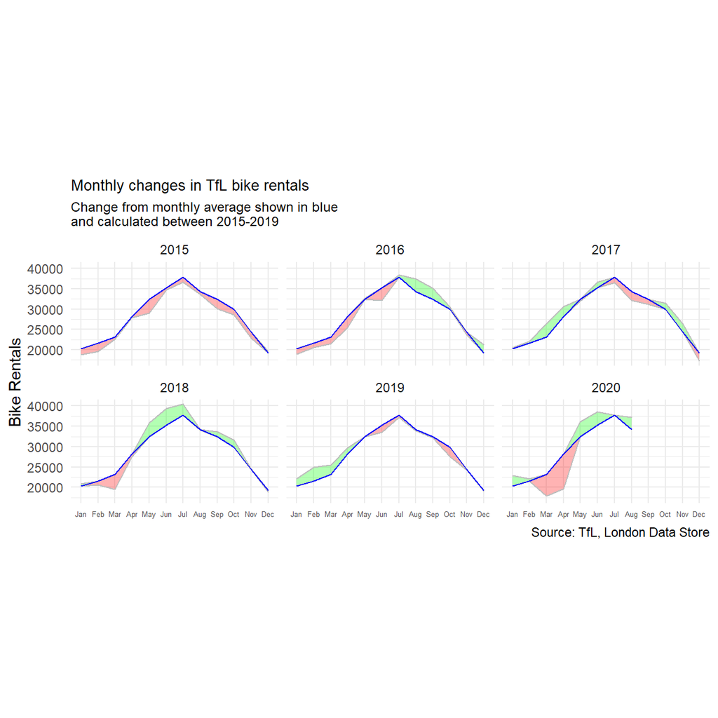

```r
bike_left_join_2$month <- as.numeric(bike_left_join_2$month)
bike_left_join_2$month <- as.factor(bike_left_join_2$month)

ggplot(data=bike_left_join_2, aes(x=month , y=year_avgMonth, group=1)) + facet_wrap(~year) +
labs(x=NULL, y="Bike Rentals", caption="Source: TfL, London Data Store", title="Monthly changes in TfL bike rentals", subtitle= "Change from monthly average shown in blue \nand calculated between 2015-2019") + theme_minimal(base_family="Arial") + theme (plot.title = element_text(size=10), plot.subtitle = element_text(size=9))+
  #+ geom_line(aes(x=month, y = year_avgMonth), size=1.2, colour="blue") +
#+ geom_line(aes(x=month, y=avgMonth), color="black", size=1.2)
  geom_ribbon(aes(ymin = year_avgMonth + if_else(diff_month < 0, diff_month, 0),
                  ymax = year_avgMonth), color ="grey", fill = "red", alpha = 0.3) +
  geom_ribbon(aes(ymin = year_avgMonth,
                  ymax = year_avgMonth + if_else(diff_month > 0, diff_month, 0)),color ="grey", fill = "green", alpha = 0.3)+ theme(aspect.ratio=0.5) + theme(axis.text.x= element_text(size=5)) +
  scale_x_discrete(labels=c("Jan", "Feb", "Mar", "Apr", "May", "Jun", "Jul", "Aug", "Sep", "Oct", "Nov", "Dec"))+ geom_line(color="blue")
```

For both of these graphs, we calculate the expected number of rentals per week or month between 2015-2019 and then, see how each week/month of 2020 compares to the expected rentals. More specifically, we use the calculation `excess_rentals = actual_rentals - expected_rentals`.

We used means as expected rentals as the data is approximaately normally distributed.

```r
bike_filtered_week <- bike %>%
                  filter(year %in% c(2015: 2020)) %>%
                  group_by(year, week) %>%
                  summarise(avgWeek_filtered_week=mean(bikes_hired))

bike_weekly_average <- bike_filtered_week %>%
                  filter(year %in% c(2015: 2019)) %>%
                  group_by(week) %>%
                  summarise(avgWeek_weekly_average=mean(avgWeek_filtered_week))

bike_joined_full <- left_join(bike_filtered_week, bike_weekly_average, by = "week")


bike_joined_full_2 <- bike_joined_full %>%
  mutate(excessrentalspercent = (avgWeek_filtered_week - avgWeek_weekly_average)*100/avgWeek_weekly_average)
```

Finally, we produce the plots.

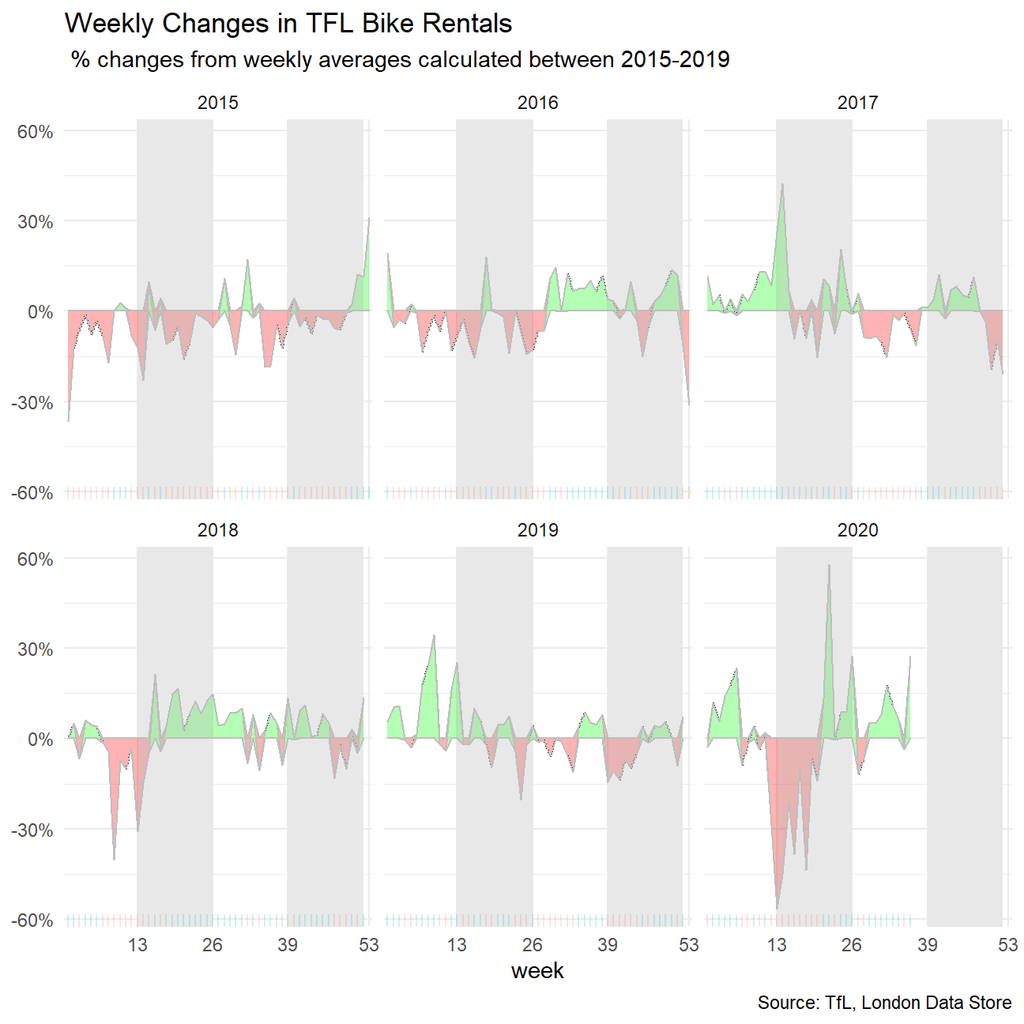

```r
ggplot(bike_joined_full_2, aes(x=week, y=excessrentalspercent)) +
  labs(title= "Weekly Changes in TFL Bike Rentals", subtitle=" % changes from weekly averages calculated between 2015-2019", x="week", y=NULL, caption="Source: TfL, London Data Store") +
  facet_wrap(~year)+ geom_line(fill="black") +
  theme_minimal() +
  geom_ribbon(aes(ymin = excessrentalspercent - if_else(excessrentalspercent < 0, excessrentalspercent, 0),
                  ymax = excessrentalspercent), color ="grey", fill = "red", alpha = 0.3) +
  geom_ribbon(aes(ymin = excessrentalspercent,
                  ymax = excessrentalspercent - if_else(excessrentalspercent > 0, excessrentalspercent, 0)),color ="grey", fill = "green", alpha = 0.3) +
   scale_x_discrete(limits = c(13, 26, 39, 53)) +
  geom_rect(xmin=13, xmax=26, ymin=-150, ymax=150, fill="grey", alpha=0.01) +geom_rect(xmin=39, xmax=52,ymin=-150, ymax=150,
                                                                                          fill="grey", alpha=0.01) +
  geom_rug(sides="b", aes(colour=ifelse(excessrentalspercent > 0, "red", "green")), alpha=0.2) +
  theme(legend.position='none') +
  scale_y_continuous(labels = function(x) paste0(x, "%"))
```

# Details

- Who did you collaborate with: Keshav, Ilana, Julia, Jasper, Aleksander, Xiyi
- Approximately how much time did you spend on this problem set: 10-15 hours
- What, if anything, gave you the most trouble: Knitting